# R Data Training: Part 3

## Aesthetics

Next we are going to determine what dimensions in the dataset are going to be mapped onto the **aesthetics** of our graph.

“Aesthetics” is one of a number of abstract concepts that are used in ggplot2, many of which might seem strange at first. Attaching these aesthetics to the dimensions or columns in our dataset is what is going to bring our data to life.

The most common aesthetics are position aesthetics, the columns that map to the `x` and `y` coordinates on your graph. Another common aesthetic, the `colour` aesthetic, determines the colour of lines and dots that you may see in a scatter plot or line graph for instance.

We add aesthetics to our dataset using the `aes()` function. We call the `aes()` function as an argument to our `ggplot()` function.

So for instance, you can assign the column `YoY` to the y-axis and `Date` to the x-axis using `aes(x = Date, y = YoY)`.

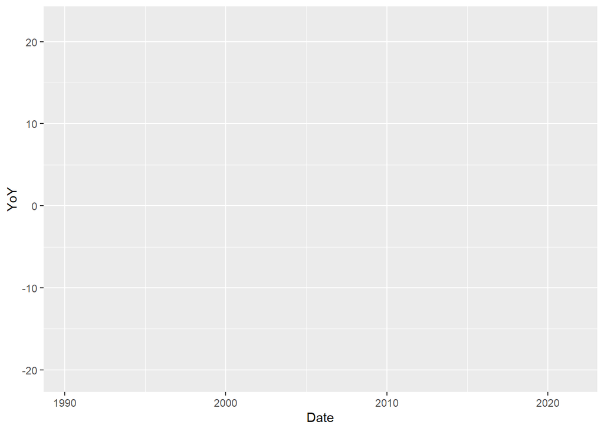

```r
data_sectors %>%
  filter(Sector == "total") %>%
  ggplot(aes(x = Date, y = YoY))
```

> Tip: Make sure you determine your aesthetics using the `aes()` function, otherwise you will get an error message.

When we run the code, we now have added axes to the plot. We can see the impact of the `x` and `y` aesthetic. We can’t see the data itself, yet, because we haven’t specified how it should be presented. We need to add a **layer** to our plot that determines how the data points look.

## Geoms

That layer is going to be a **geom** type. “Geoms” describe the *geometric objects* that represent the data. It’s probably easiest to think of geoms as what you might think of as the “chart type”.

The simplest geom is the `blank` geom, which just returns an empty canvas. Note how all geom layers begin with `geom_`:

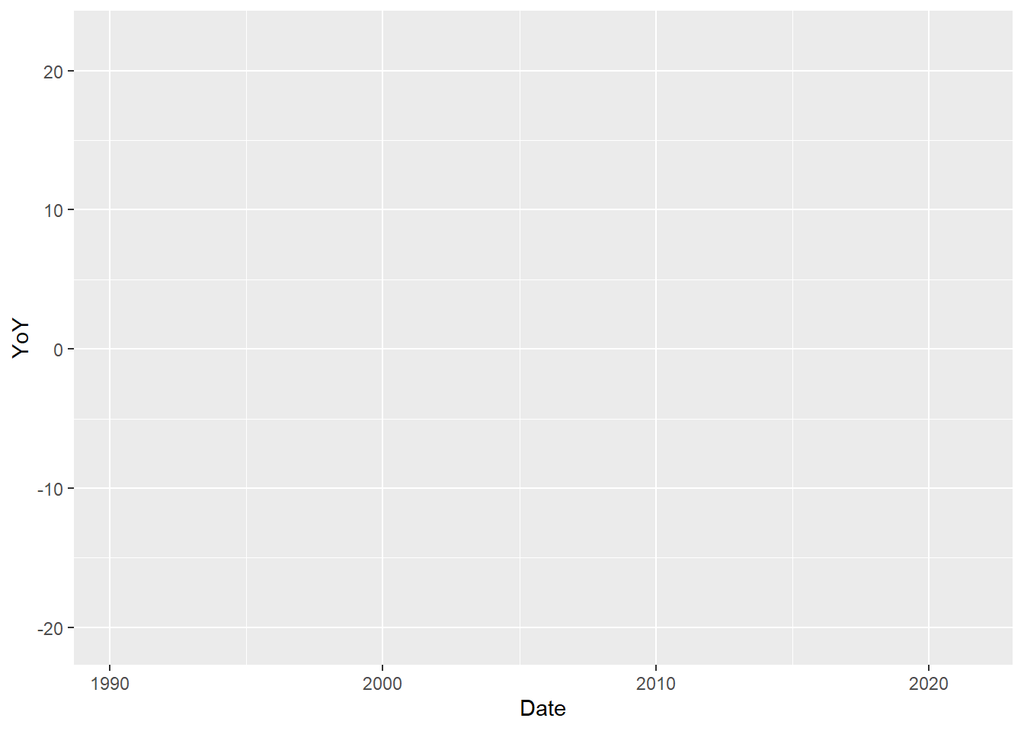

```r
data_sectors %>%
  filter(Sector == "total") %>%
  ggplot(aes(x = Date, y = YoY)) +
  geom_blank()
```

We can create a line chart by simply replacing `geom_blank()` with `geom_line()`:

```
## Warning: Removed 4 row(s) containing missing values (geom_path).
```

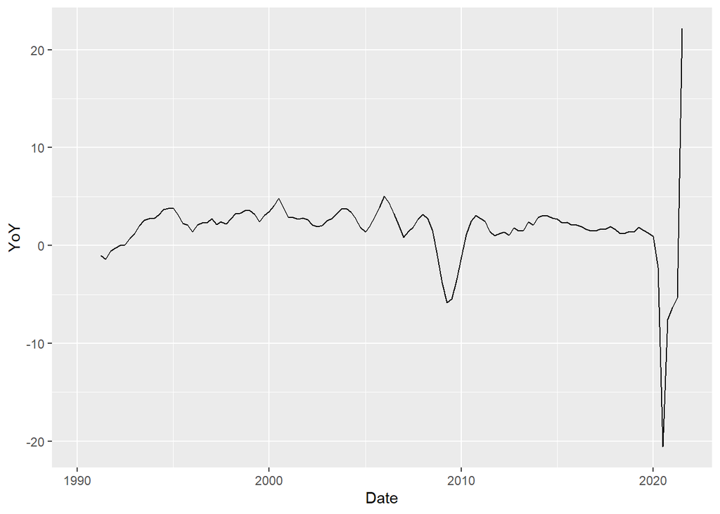

```r
data_sectors %>%
  filter(Sector == "total") %>%
  ggplot(aes(x = Date, y = YoY)) +
  geom_line()
```

Notice the warning that comes up because we have some *NA* values at the start of our dataset. We can get rid of those by using the `na.rm` argument within the geom.

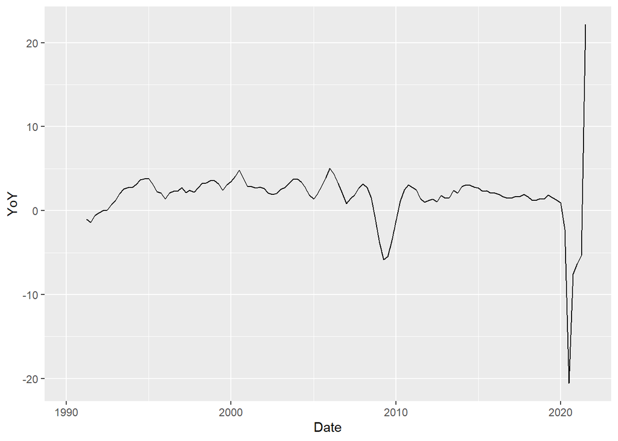

```r
data_sectors %>%
  filter(Sector == "total") %>%
  ggplot(aes(x = Date, y = YoY)) +
  geom_line(na.rm = TRUE)
```

And we can easily change our chart type by experimenting with geoms:

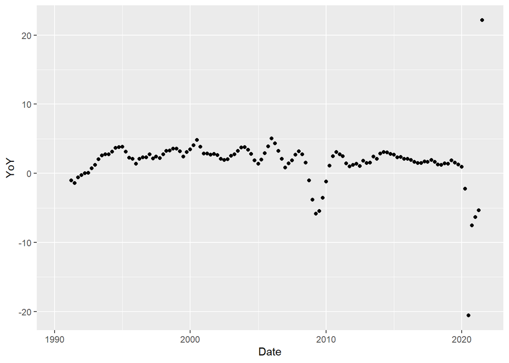

```r
data_sectors %>%
  filter(Sector == "total") %>%
  ggplot(aes(x = Date, y = YoY)) +
  geom_point(na.rm = TRUE)
```

We can easily scroll through the list of available geoms in `ggplot2` by typing `geom_` into the R console. Alternatively, we can look at our `ggplot2` cheat sheet for examples.

**Exercise break**

**Complete the following exercises & remember: ask a question in the chat box if you’re stuck, and a trainer should be able to help.**

1. Make a line chart of year-on-year(YoY) total GDP growth over time (hint: remember your [ggplot cheat sheet](https://github.com/rstudio/cheatsheets/raw/master/data-visualization-2.1.pdf))
2. Make a bar chart of `QoQ` GDP growth across sectors in 2020Q2 (hint: make sure you choose the correct geom, and remember your [dplyr cheat sheet](https://github.com/rstudio/cheatsheets/raw/master/data-transformation.pdf), too).

**End of exercises**

We can “map” variables to *other* aesthetics, too, beyond just `x` and `y`. For example, the `colour` aesthetic can be used to apply colour to our chart.

Now lets try and include all the sectors data in one chart, and `colour` the lines according to the different `Sectors`:

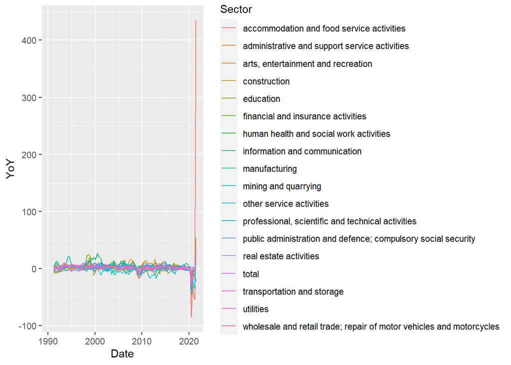

```r
ggplot(data = data_sectors, aes(x = Date, y = YoY, colour = Sector))+
  geom_line(na.rm = TRUE)
```

You can click on the `Zoom` button above the plot to get a better look. But you probably wouldn’t want to visualise all your data in the same chart in this way! We’ll come on later to a better way to do this.

The ggplot2 cheat sheet provides the available chart aesthetics for each `geom` type. You may notice that the `colour` aesthetic isn’t applicable to some other geoms. For bar charts (`geom_bar()`), the `fill` aesthetic is used to represent colour instead. (A good way to think about it is that you are going to reach for the `fill` aesthetic when you typically would reach for the “shape fill” option in the Microsoft suite. `colour`, on the other hand, is equivalent to the “shape outline” option in the Microsoft suite).

Some geoms take parameters that are specific to that geom. For instance the `geom_histogram()` has a `bins` argument:

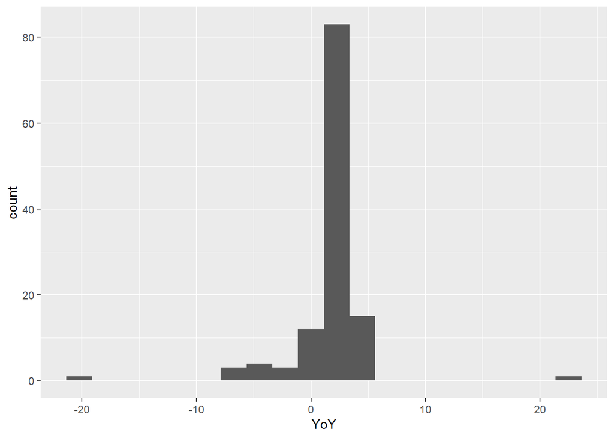

```r
data_sectors %>%
  filter(Sector == "total") %>%
  ggplot(aes(x = YoY)) +
  geom_histogram(bins = 20, na.rm = TRUE)
```

You can see there are two observations that are major outliers. Hint: what has caused a huge fall and subsequent bounce back in economic growth recently?

Some arguments apply *across* different `geoms`. A common parameter you will come across is the `alpha` argument. This will determine how transparent the “ink” in your geom is:

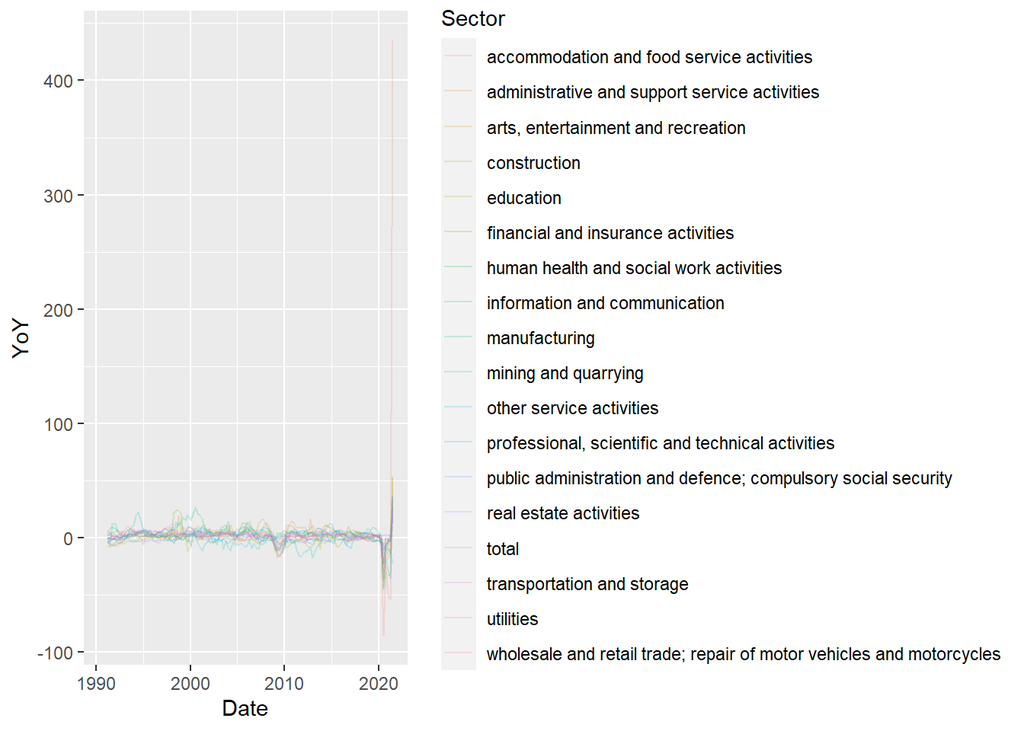

```r
ggplot(data = data_sectors, aes(x = Date, y = YoY, colour = Sector)) +
  geom_line(alpha = 0.2, na.rm = TRUE)
```

Note that aesthetics can be mapped to **values** (rather than **variables** in our data), *outside* of `aes()` commands. In the above case, we chose to set `alpha` (point transparency) to an absolute value, rather than to depend on a variable.

## Facetting

We have predominantly used **aesthetics** to explore aditional variables in our charts, so far. Another way to do this (particularly useful for categorical variables) is to split your plot into **facets**, displaying subsets of the data across several “windows”.

The simplest way to “facet” a chart is to divide it into subplots by a *single* variable using `facet_wrap()`. The first argument to this function is actually a formula explaining how to facet the preceding chart.

Let’s return to an earlier line chart

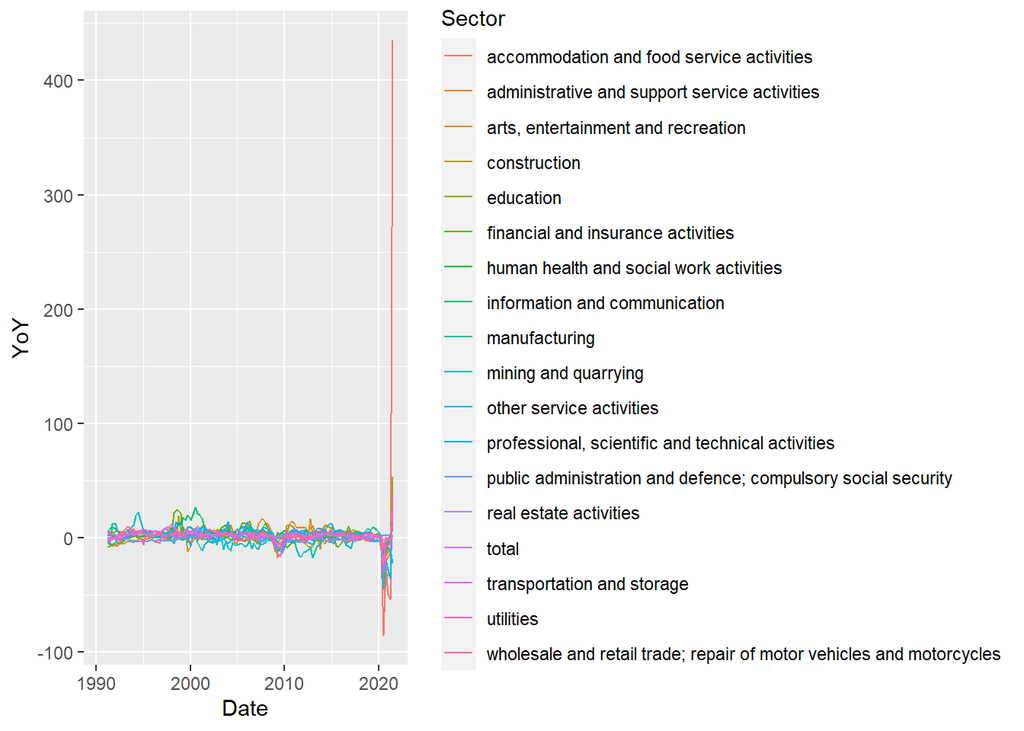

```r
ggplot(data = data_sectors, aes(x = Date, y = YoY, colour = Sector))+
  geom_line(na.rm = TRUE)
```

Now, lets `facet` the chart by `Sector` rather than using `colour`:

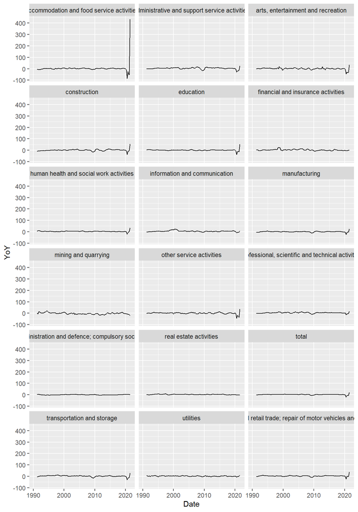

```r
ggplot(data = data_sectors, aes(x = Date, y = YoY))+
  geom_line(na.rm = TRUE) +
  # add facet layer with 3 columns of charts
  facet_wrap(~ Sector, ncol = 3)
```

The sector names aren’t fitting on the panels, so lets use an additional argument in the `facet_wrap` function to wrap them over multiple lines. You need to define the maximum number of characters on each line.

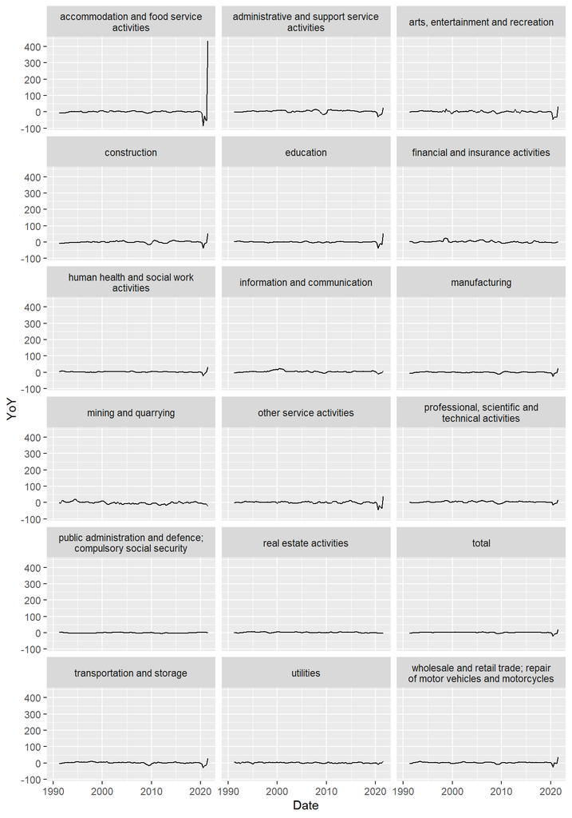

```r
ggplot(data = data_sectors, aes(x = Date, y = YoY))+
  geom_line(na.rm = TRUE) +
  # add additional argument to wrap the sector names
  facet_wrap(~ Sector, ncol = 3, labeller = labeller(Sector = label_wrap_gen(35)))
```

By default, the charts will all have the same axis range, so going from +400% to -100% in this example. But that means it’s harder to see the moves in some of the sectors that haven’t experienced such large swings. To let R choose the axis range for each chart, we can include a `scales` argument in the `facet_wrap` function:

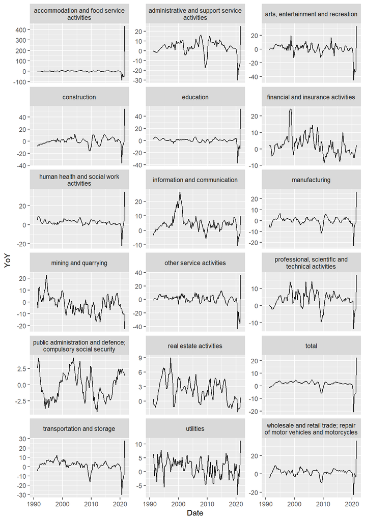

```r
ggplot(data = data_sectors, aes(x = Date, y = YoY))+
  geom_line(na.rm = TRUE) +
  facet_wrap( ~ Sector, ncol = 3, labeller = labeller(Sector = label_wrap_gen(35)), scales = "free_y")
```

**Exercise break**

**Complete the following exercises & remember: ask a question in the chat box if you’re stuck, and a trainer should be able to help.**

1. Create a line chart of the % change vs pre-Covid since 2019Q4 (our `PreCovChg` variable) and map `Sector` to a suitable aesthetic (e.g. `colour` or `linetype`)?
2. What happens if you set `colour` *outside* of `aes()`? Try setting it to a simple colour in quote marks (e.g. “red”).
3. Can you edit the code so that the chart is “facetted” by `Sector`, instead of being represented by an aesthetic`?

**End of exercises**

## Graphics for Communication

Once we have the base chart down, we should make it “pretty” and format it correctly so that we can communicate our understanding effectively to others. Here, you’ll learn some tricks of the trade to start turning exploratory graphics into expository graphics.

> Tip: Producing a pretty chart takes effort. Producing one that helps rather than hinders understanding takes expertise. Themes will get us so far, but if you are interested in improving your data viz skills fundamentally, consider a good general book like Cairo’s [The Truthful Art](https://amzn.com/0321934075).

We’ve spent time looking at YoY growth rates across sectors, but now we want to examine the impact of the pandemic more closely. So let’s start with our bar chart created in the exercise earlier, that looks only at quarterly growth in 20Q2 (when the pandemic hit).

As a reminder, here’s what that code should have looked like:

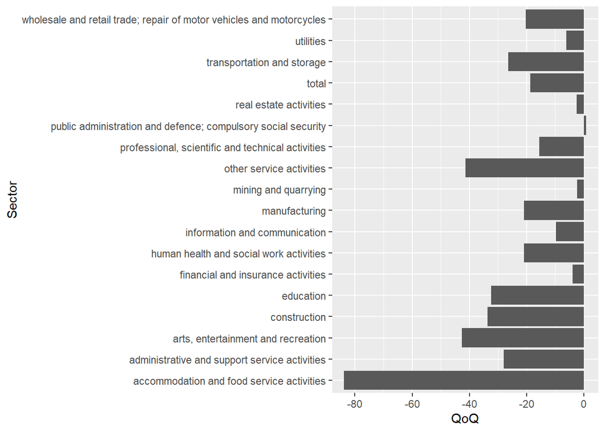

```r
data_sectors %>%
  filter(Date == as.Date("2020-06-30")) %>%
  ggplot(mapping = aes(x = QoQ, y = Sector)) +
  geom_col()
```

### Labels

We add/edit chart labels using the `labs()` function. As well as `x` and `y` labels we can add titles, captions (useful for referencing sources) and so on, all in the same function:

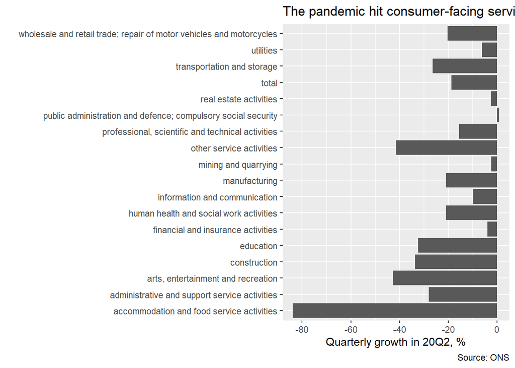

```r
data_sectors %>%
  filter(Date == as.Date("2020-06-30")) %>%
  ggplot(mapping = aes(x = QoQ, y = Sector)) +
  geom_col() +
  # add chart labels
  labs(title = "The pandemic hit consumer-facing services the hardest",
       caption = "Source: ONS",
       y = "",
       x = "Quarterly growth in 20Q2, %")
```

The title isn’t fitting on here, so we can wrap it over multiple lines using the `str_wrap` function from the `stringr` package we used in the first session. As with the `labeller` argument in the `facet_wrap` function above, we need to define the maximum number of characters for each line.

We can also make it easier to see which sectors had the biggest hits by ordering by size:

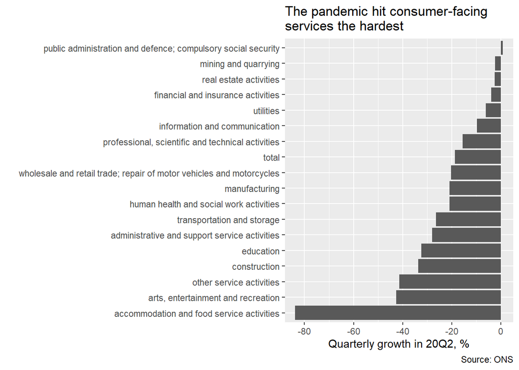

```r
data_sectors %>%
  filter(Date == as.Date("2020-06-30")) %>%
  ggplot(mapping = aes(x = QoQ, y = reorder(Sector, QoQ))) + # reorder sectors by size of QoQ hit
  geom_col() +
  labs(title = str_wrap("The pandemic hit consumer-facing services the hardest", 35), # wrap the plot title
       caption = "Source: ONS",
       y = "",
       x = "Quarterly growth in 20Q2, %")
```

This was very simple as we wanted to reorder by size, but more generally you can control the ordering of the series in your charts using **factors**. We won’t cover these here but there is cheat sheet available for those interested: [factors cheat sheet](https://raw.githubusercontent.com/rstudio/cheatsheets/master/factors.pdf)

We can also put data labels onto our chart using `geom_text()`

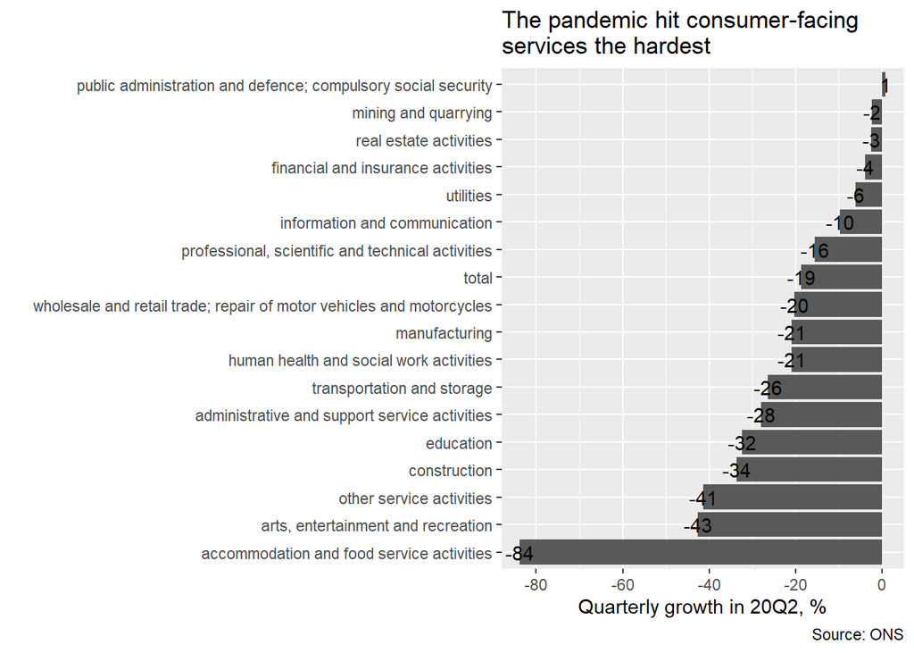

```r
data_sectors %>%
  filter(Date == as.Date("2020-06-30")) %>%
  ggplot(mapping = aes(x = QoQ, y = reorder(Sector, QoQ))) +
  geom_col() +
  labs(title = str_wrap("The pandemic hit consumer-facing services the hardest", 35),
       caption = "Source: ONS",
       y = "",
       x = "Quarterly growth in 20Q2, %")+
  geom_text(aes(label = round(QoQ, 0))) # Add data labels
```

### Scales

Another way to improve communication is to adjust (or replace) your scales.

Scale functions helpfully begin with `scale_`, then make reference to an `aesthetic`, and finally describe some kind of scale transformation.

We could consider reversing the `QoQ` growth rates so that the bars start next to the sector names. `QoQ` is mapped to the `x` aesthetic, so we can try using `scale_x_reverse()`:

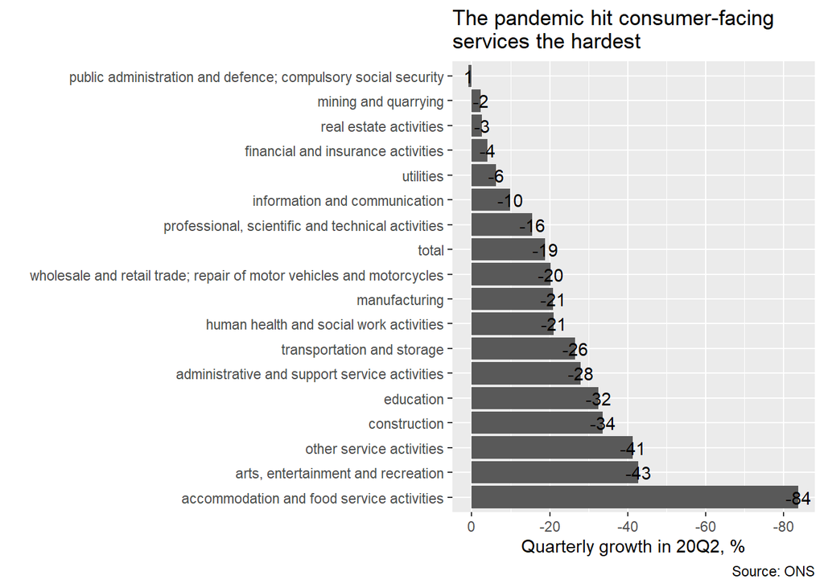

```r
data_sectors %>%
  filter(Date == as.Date("2020-06-30")) %>%
  ggplot(mapping = aes(x = QoQ, y = reorder(Sector, QoQ))) +
  geom_col() +
  labs(title = str_wrap("The pandemic hit consumer-facing services the hardest", 35),
       caption = "Source: ONS",
       y = "",
       x = "Quarterly growth in 20Q2, %")+
  geom_text(aes(label = round(QoQ, 0))) +
  #reverse x-axis
  scale_x_reverse()
```

> Many of the shortcuts for quickly formatting graph scales, are in the `scales` package (which is installed with `ggplot2`).

### Themes

The next trick is to use **themes**. Themes apply a whole set of formatting changes to your plots. `ggplot2` comes with a whole set of themes preloaded. One of the easiest ways to scroll through them is using tab. Type `theme_` and press `tab`.

There is a nice R package called `ggthemes` that has a number of additional themes. Let’s install/load that:

```r
install.packages("ggthemes")
```

```r
library(ggthemes)
```

Now we can quickly and easily make our plot look like a plot from the Economist. It’s as simple as adding a `theme_` layer to an existing chart, `theme_economist()` in this case:

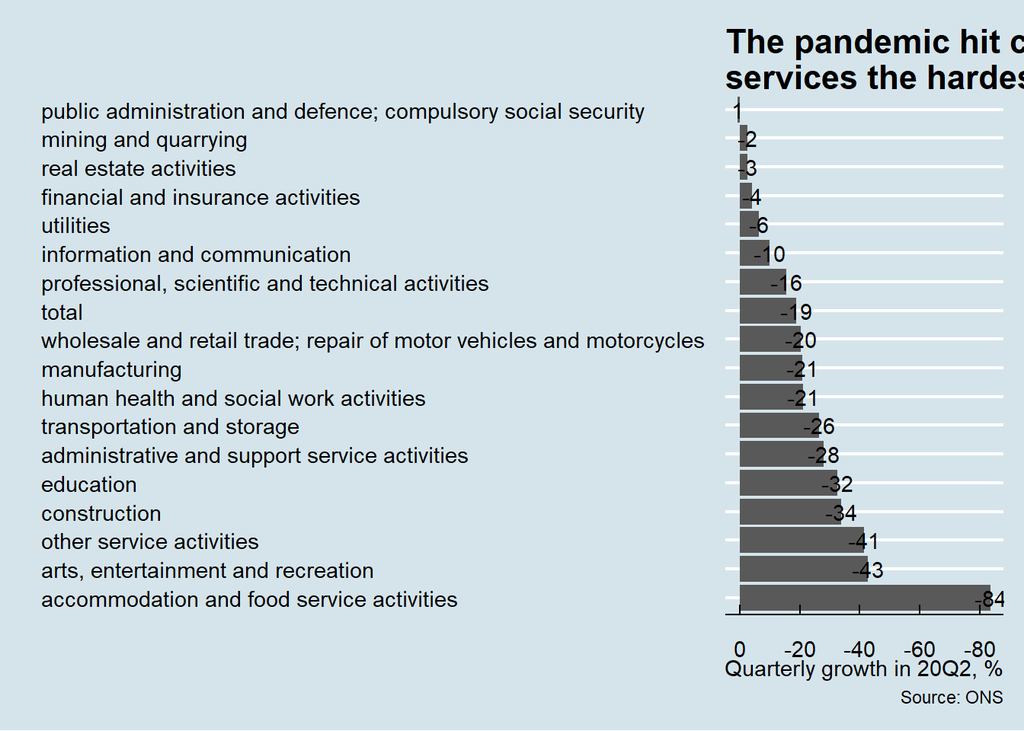

```r
data_sectors %>%
  filter(Date == as.Date("2020-06-30")) %>%
  ggplot(mapping = aes(x = QoQ, y = reorder(Sector, QoQ))) +
  geom_col() +
  labs(title = str_wrap("The pandemic hit consumer-facing services the hardest", 35),
       caption = "Source: ONS",
       y = "",
       x = "Quarterly growth in 20Q2, %")+
  geom_text(aes(label = round(QoQ, 0))) +
  scale_x_reverse() +
  # apply economist theme
  theme_economist()
```

As well as overhauling your chart theme like so, it’s possible to isolate specific theme elements for customisation using `theme()`. Let’s explore it by writing `theme()` in the console, and pressing `tab` inside the function’s parentheses.

The various argument names consists of the parts of the graph you want to format, for example:

- If we want to format the caption text, we choose the `plot.caption` argument.
- Because we want to format some *text* (rather than, say, a line), we use the `element_text()` function to access options suitable when formatting text (press `tab` inside `element_text()` to see the options available).
- Let’s make the title a smaller font size so that it fits on the chart by choose the `size` parameter and setting to *12*. And make the other font size a little smaller too.
- Let’s also make the caption italic by choosing the `face` parameter and setting to *italic*.

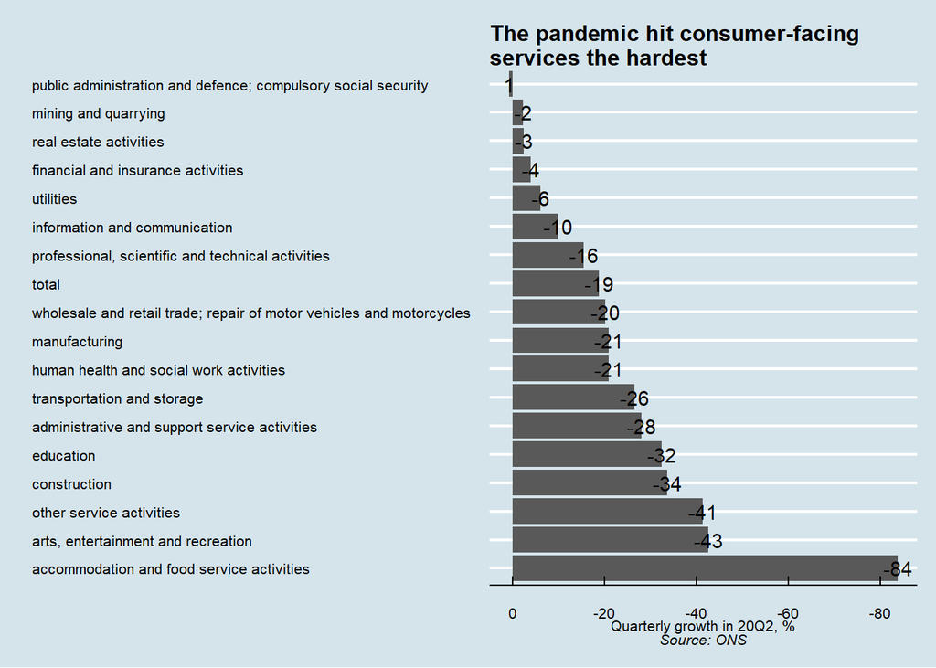

```r
data_sectors %>%
  filter(Date == as.Date("2020-06-30")) %>%
  ggplot(mapping = aes(x = QoQ, y = reorder(Sector, QoQ))) +
  geom_col() +
  labs(title = str_wrap("The pandemic hit consumer-facing services the hardest", 35),
       caption = "Source: ONS",
       y = "",
       x = "Quarterly growth in 20Q2, %")+
  geom_text(aes(label = round(QoQ, 0))) +
  scale_x_reverse() +
  theme_economist() +
  # modify chart theme
  theme(text = element_text(size = 8),
        plot.title = element_text(size = 12),
        plot.caption = element_text(face = "italic"))
```

**Exercise break**

**Complete the following exercises & remember: ask a question in the chat box if you’re stuck, and a trainer should be able to help.**

1. Pick up from the facetted chart created in the last exercise. If you need it, the code solution is here:

```r
data_sectors %>%
  filter(Date >= "2019-12-31") %>%
  ggplot(mapping = aes(x = as.Date(Date), y = PreCovChg)) +
  geom_line() +
  facet_wrap( ~ Sector, ncol = 3, labeller = labeller(Sector = label_wrap_gen(35)), scales = "free_y")
```

2. Add some suitable labels to this chart using `labs()` (hint: get help with this function by typing `?labs`).
3. Change the format of the labels on the axis representing `Date` (hint: explore the *Scales* section of your [ggplot cheat sheet](https://github.com/rstudio/cheatsheets/raw/master/data-visualization-2.1.pdf) for a function to do this, and remember the date formats from session 1).
4. Choose a theme you like! Try typing `theme_` to bring up a list of available themes to try.
5. Try editing specific elements of your theme by adding a `theme()` function to your chart (hint: you will need to use the correct `element_` function for the type of chart element you are customising).

**End of exercises**

### Bank-style charts

An internal R package, `boeCharts`, is built on top of `ggplot2` to make it easier to align with Bank style guidance without sacrificing reproducibility.

Let’s try subbing out `theme_economist` for `theme_overground`, a theme mimicking [Bank Overground](https://www.bankofengland.co.uk/bank-overground) publication charts:

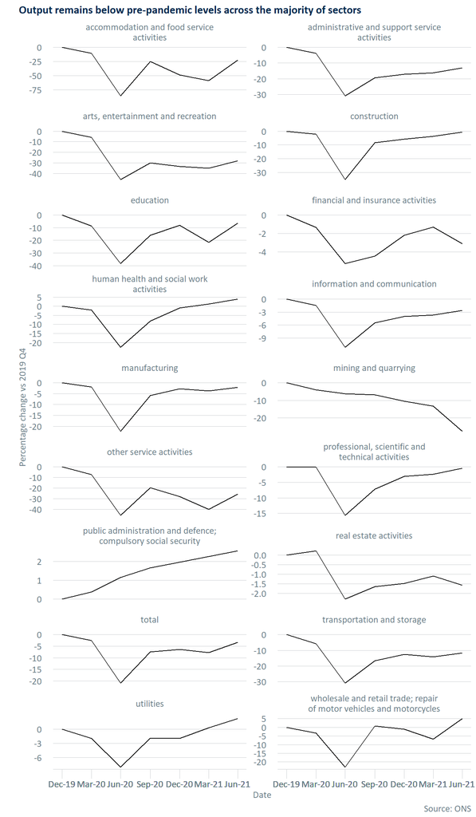

```r
library(boeCharts)

data_sectors %>%
  filter(Date >= "2019-12-31") %>%
  ggplot(mapping = aes(x = as.Date(Date), y = PreCovChg)) +
  geom_line() +
  facet_wrap( ~ Sector, scales = "free_y", ncol = 2, labeller = labeller(Sector = label_wrap_gen(35))) +
  labs(title = "Output remains below pre-pandemic levels across the majority of sectors",
       caption = "Source: ONS",
       y = "Percentage change vs 2019 Q4",
       x = "Date")+
    scale_x_date(breaks = data_sectors$Date, date_labels = "%b-%y")+
  # add bank overground theme
  theme_overground(base_size = 10, plot_title_size = 12, strip_text_size = 10, caption_size = 10)
```

To get started with the package, start at the [README](https://almplatform/tfs/UnmanagedCollection/Shared%20Analytical%20Code/_git/boeCharts?path=%2FREADME.md) page.

## Saving and exporting charts

Once you’ve finished charting your analysis, you might want to save those charts for future use, or share them with your colleagues. There are two main ways to do this.

First, you can simply click on the `Export` button in the Plots tab. This has the option of saving as an image or PDF, or simply copying to your clipboard. If we choose `Save as image` you will then see options to choose the image format, the file location, and settings for the height and width.

Second, you can use the `ggsave()` function from the `ggplot2` package. If you look at the help page (using `?ggsave`) you can see the different options available to you when saving, including setting the format, size and resolution.

Let’s assign our bar chart to an object called `my_plot` and then try saving it to our data folder.

```r
data_sectors %>%
  filter(Date == as.Date("2020-06-30")) %>%
  ggplot(mapping = aes(x = QoQ, y = reorder(Sector, QoQ))) +
  geom_col() +
  labs(title = str_wrap("The pandemic hit consumer-facing services the hardest", 35),
       caption = "Source: ONS",
       y = "",
       x = "Quarterly growth in 20Q2, %")+
  geom_text(aes(label = round(QoQ, 0))) +
  scale_x_reverse() +
  theme_economist() +
  theme(text = element_text(size = 8),
        plot.title = element_text(size = 10),
        plot.caption = element_text(face = "italic")) -> my_plot
```

```r
ggsave("my_plot.jpeg", plot = my_plot, path = "data")
```

# Support for R users in the Bank

There is a wide range of support available for R users in the Bank which can help as you get started using R. Through the Bank’s Data Community, you can access peer support from other R users in the following ways:

- **Posting questions on the Data Community Forum** - there is no such thing as a silly question! Don’t be afraid to post as others may be wondering about the same thing. There are lots of R enthusiasts within the Data Community happy to help answer questions, especially for colleagues getting started. Just make sure you give as much information as possible about the problem you are having to help get the best answer. This wiki page has some helpful advice for asking good questions [How to ask for help on the Data Community](https://bankexchange/groups/1067/Pages/Wiki/How%20to%20ask%20for%20help%20on%20the%20Data%20Community.aspx)
- **R User Community** – the R user group has a monthly meeting at which colleagues using R come together to share work they have done in the tool, discuss challenges being faced, work collaboratively together and generally help build a network of support for R users. These sessions are arranged through the Data Community by the Analytics Enablement Hub (AEH) Training and Comms team. Look out for the dates being advertised on the Data Community and the Bankwide events page. Alternatively, you can email AnalyticsEnablementHub to be added to the series of meetings.
- **R wiki** – within the Data Community wiki pages, there is a wealth of information to help you use R. This can be accessed here [R World](https://bankexchange/groups/1067/Pages/Wiki/R%20World.aspx)
- **LinkedIn Learning** – everyone in the Bank can access LinkedIn Learning (if you have not activated your account yet this is simple to do and only needs to be done once). We have a ‘collection’ of R videos which complement this Beginner course and also cover some additional content you may find useful. This collection can be accessed [here](https://www.linkedin.com/learning/collections/enterprise/1~AAAAAAULv5o=697077?u=84656026)

As you use R more, we recommend that you attend our ‘Git for Beginners’ course as this will help you to understand the importance of version control best practice using Git. You can book onto this course via [L&D Online](https://boe.hemsleyfraser.co.uk/Course/CourseDetail?resourceid=33462)

> *<sub>Fin.</sub>*

# Learning and trouble shooting

## Where to ask for help

There will be times when you code doesn’t work and you cannot understand why. It will be tempting to spend hours googling and straining to solve your issue. Do not do this. If you are stuck for more than 15 minutes, either go away, do something else and come back, or ask someone:

1. Google (with care). Links to stack overflow are often very helpful.
2. Ask a colleague
3. Ask a question on the Bank’s [data community](http://dse/groups/1067/SitePages/Home.aspx) - check out [why to join](http://intranet/Banknav/IML.asp?svr=BOE-DMS&db=Analytical&id=8010953&v=0) and [how to use](http://intranet/Banknav/IML.asp?svr=BOE-DMS&db=Analytical&id=8026209&v=0)
4. Look up a relevant tutorial

## Where to learn more/tutorials

For a one-stop-shop on all things R, explore the [R World Wiki](http://dse/groups/1067/Pages/Wiki/R%20World.aspx) on the Data Community page.

R in general:

- [R for data science](http://r4ds.had.co.nz/)
- [Rstudio cheat sheets](https://www.rstudio.com/resources/cheatsheets/)

Visualisation (`ggplot2`):

- [Cheat sheet](https://github.com/rstudio/cheatsheets/raw/master/data-visualization-2.1.pdf)
- [Website](https://ggplot2.tidyverse.org/)